# Counting points in multipolygon shapefiles for choropleth mapping

Maps

Eukaryota

Animalia

Chordata

Aves

Choropleth maps are an excellent way to visualise numbers of observations, but when using point data, calculating the number of points in each polygon can be difficult when using shapefiles. Here we demonstrate how to extract and summarise the number of points in each polygon to create a choropleth map.

Olivia Torresan , Dax Kellie  
2023-01-12

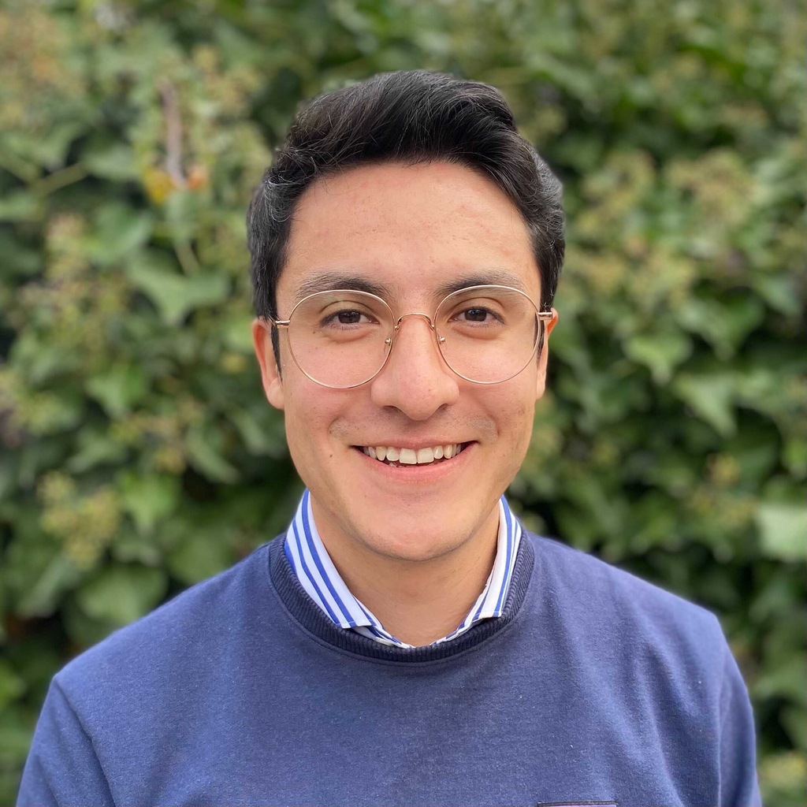

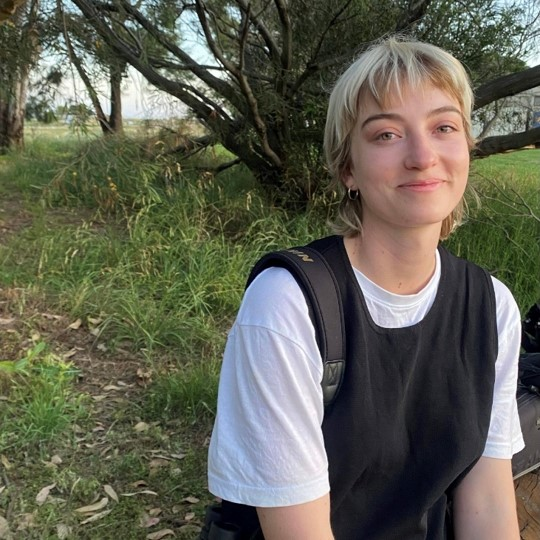

#### Author:

[Olivia Torresan](https://labs.ala.org.au/people/Torresan_Olivia/index.html) [Dax Kellie](https://labs.ala.org.au/people/Kellie_Dax/index.html)

#### Date:

12 January, 2023

Choropleth maps are an excellent way to visualise differences in variables (eg. number of species observed) across several geographic regions (eg. countries, states, study areas). Often, creating a choropleth map from species observations requires two things:

1. A shapefile - a file with vector data of a specific geographic location, with detailed info of its geographic features
2. Species observations recorded as point data - the specific longitude and latitude coordinates of where an individual was observed.

However, to create a choropleth map of species observations requires us to summarise our points to a single statistic for each polygon of our shapefile. This conversion from points to polygons can sometimes be tricky!

Here, we show you how to extract and count the number of points inside each polygon of a shapefile to create a choropleth map of the total number of species observations in each suburb of the Australian Capital Territory (ACT).

## Download data

First we will load the R packages that we need:

```r
library(feathers)
library(galah)
library(here)
library(rmapshaper)
library(tidyverse)
library(sf)
```

### Download shapefile

Next we will need a shapefile. You can find many shapefiles online from reputable sources. For this example, I’ve downloaded a shapefile of suburb boundaries in the city of Canberra, ACT from the [ACT’s open-access map database](https://www.actmapi.act.gov.au/download.html).

Usually when you download a shapefile, it is compressed within a zip folder. Save this downloaded zip folder in a local folder inside your current [R project](https://r4ds.had.co.nz/workflow-projects.html). If you need to unzip your folder, you can do so with the following code:

```r
zip_folder <- here("folder-name", "shapefile-folder-name.zip")
output_dir <- "folder-name-to-save-unzipped-files"
unzip(zip_folder, exdir = output_dir)
```

Now we load this unzipped shapefile into R. To save space, we’ll remove some complexity from our shapefile polygons with `ms_simplify()` from the `{rmapshaper}` package.

The `actsuburbs` shapefile contains both suburb boundaries and “district” boundaries, which can encompass several suburbs. To avoid confusion, we will remove districts using `filter(LOC_CLASS != "District")`. We’ll also use `st_make_valid()` to make sure any weird invalid geometries in our shapefile are made valid, and therefore plot correctly.

```r
actsuburbs <- st_read(here("folder-name",
                           "folder-name-2",
                           "shapefilename.shp") |>
                     ms_simplify(keep = 0.1) |>
  st_transform(crs = st_crs("WGS84")) |>
  st_make_valid() |>
  filter(LOC_CLASS != "District")
```

Now to see if our shapefile plots correctly, we can use `geom_sf()` (and it looks like it does!)

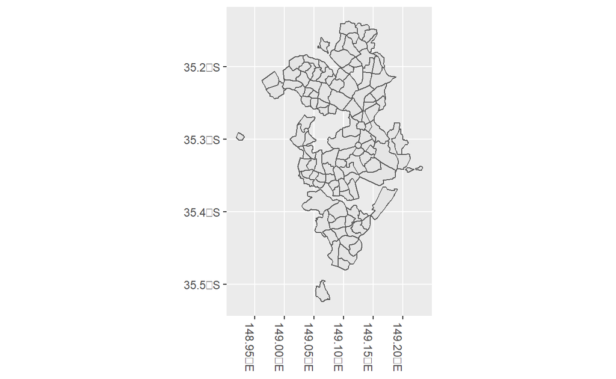

```r
ggplot() +
  geom_sf(data = actsuburbs) +
  theme(axis.text.x = element_text(angle = -90, hjust = 0))
```

### Download species observations

Next let’s use the [{galah} package](http://galah.ala.org.au/) to download bird occurrence records from the [Atlas of Living Australia (ALA)](https://www.ala.org.au/).

We can download all *Aves* (bird) data provided by BirdLife Australia within the ACT by using `galah_filter()` to narrow our download. We’ll also add ALA’s data profile, or what the ALA calls a set of data quality filters to remove suspicious records, using `galah_apply_profile(ALA)`.

You will need to provide a [registered email with the ALA](https://auth.ala.org.au/userdetails/registration/createAccount) using `galah_config()` before retrieving records.

```r
galah_config(email = "your-email@email.com", verbose = FALSE)
```

```r
birdocc <- galah_call() |>
  galah_identify("Aves") |>
  galah_apply_profile(ALA) |>
  galah_filter(stateProvince == "Australian Capital Territory",
               dataProviderName == "BirdLife Australia") |>
atlas_occurrences()
```

For those unfamiliar with Australian geography, the ACT is located here:

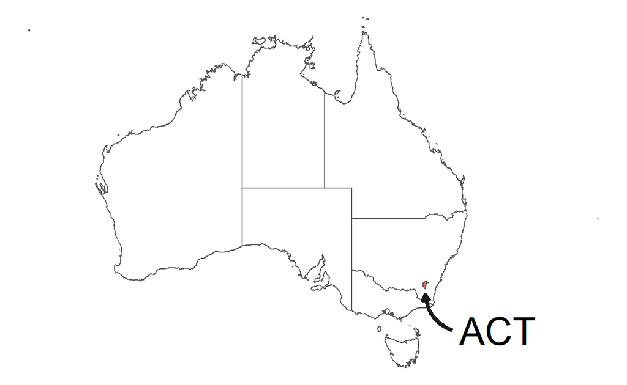

## Count points in each polygon

To prepare our data, we’ll convert each observation into a format suitable for spatial mapping. `st_as_sf()` transforms each point into an `sf` spatial object (which plots nicely with {`ggplot2`}). We’ll also make sure the points are projected to `crs = set_crs("WGS84")`, the same as our shapefile, so that the points line up correctly.

```r
bird_points_sf <- birdocc |>
  st_as_sf(coords = c("decimalLongitude", "decimalLatitude"),
  crs = st_crs("WGS84"))
```

Now we’ll find and count how many points are in each of our suburbs.

The `st_intersects()` function checks whether each point is within, or “intersects”, a specified `POLYGON` and then marks it as `TRUE` or `FALSE` in a matrix. Using `st_intersects()` in a loop with `pmap()` allows us to run `st_intersects()` on each row of a supplied list.

In our case, because each row of `actsuburbs$geometry` corresponds to each suburb, `pmap()` recursively checks which points are within each of our ACT suburbs! Adding `lengths()` around `st_intersects()` will count the number of rows returned for each suburb list, returning the total number of points that intersect each suburb. [^1]. We’ve saved this count in a new column `bird_count`.

*Note: This function takes ~3.5 minutes to run*

```r
act_counts <- actsuburbs |>
  mutate(bird_count = pmap(.l = list(x = actsuburbs$geometry),
                           .f = function(x) {
                             lengths(st_intersects(x, bird_points_sf))
                             }))

act_counts |> select(LOC_NAME, bird_count) |> head(8L) # see sample of counts
```

```
Simple feature collection with 8 features and 2 fields
Geometry type: POLYGON
Dimension:     XY
Bounding box:  xmin: 149.0563 ymin: -35.48032 xmax: 149.2188 ymax: -35.15856
Geodetic CRS:  WGS 84
   LOC_NAME bird_count                       geometry
1     Acton        670 POLYGON ((149.128 -35.28592...
2   Ainslie        120 POLYGON ((149.1374 -35.2583...
3    Amaroo         50 POLYGON ((149.1157 -35.1682...
4    Aranda         38 POLYGON ((149.0876 -35.2551...
5     Banks          0 POLYGON ((149.1019 -35.4803...
6    Barton        755 POLYGON ((149.1295 -35.3070...
7     Beard          0 POLYGON ((149.2156 -35.3407...
8 Belconnen       1521 POLYGON ((149.0789 -35.2304...
```

If we check our bird counts, we can notice that our count data is skewed because many regions have lower numbers of observations and only a few regions have very high numbers of observations.

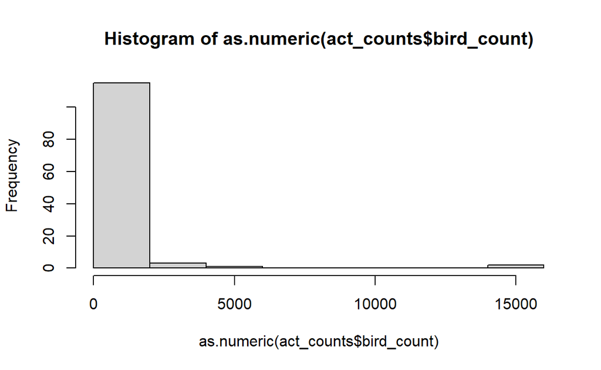

```r
hist(as.numeric(act_counts$bird_count))
```

Log transformation will reduce the skew in our data, ultimately making our final choropleth map easier to interpret.

Let’s add log-transformed counts to a new column `log_counts`. Next we’ll add a column called `counts_discrete` and use `cut()` to assign a number from 0 to 5 depending on what range each `log_counts` number falls within (0-1, 1-2, 2-3, 3-4 or 4-5). To make this easier to interpret, we’ve added labels that correspond to the un-transformed values (0, 10, 100, 1000, 10000). Finally, we replace any pesky `NA` values with 0.

```r
act_counts <- act_counts |>
  rowwise() |>
  mutate(log_counts = log10(bird_count)) |>
  mutate(counts_discrete = cut(log_counts,
                               breaks = c(0, 1, 2, 3, 4, 5),
                               labels = c(0, 10, 100, 1000, 10000),
                               include.lowest = TRUE)) |>
  replace_na(list(counts_discrete = "0"))

act_counts |> rmarkdown::paged_table() # final data frame
```

|  | LC_PLY_PID | LOC_PID | DT_CREATE | LOC_NAME | LOC_CLASS | STATE | geometry | bird_count | log_counts | counts_discrete |
| --- | --- | --- | --- | --- | --- | --- | --- | --- | --- | --- |
| 1 | lcp1ba238e2cb47 | loc6f02f098e82d | 2022-03-11 | Acton | Gazetted Locality | ACT |  |  | 2.8260748 | 100 |
| 2 | lcpe9d674c6324f | loc8af26acb532d | 2022-03-11 | Ainslie | Gazetted Locality | ACT |  |  | 2.0791812 | 100 |
| 3 | lcp22119353bf31 | locf0cacaa1119e | 2022-03-11 | Amaroo | Gazetted Locality | ACT |  |  | 1.6989700 | 10 |
| 4 | lcp56c03203575e | locf94248966b6c | 2022-03-11 | Aranda | Gazetted Locality | ACT |  |  | 1.5797836 | 10 |
| 5 | lcp7add4fb70b35 | loc76cc01c04bd2 | 2021-06-24 | Banks | Gazetted Locality | ACT |  |  | -Inf | 0 |
| 6 | lcp73b522c2c288 | loc3c05059f862a | 2022-03-11 | Barton | Gazetted Locality | ACT |  |  | 2.8779470 | 100 |
| 7 | lcp350db8965543 | loca5dacbe1db50 | 2021-06-24 | Beard | Gazetted Locality | ACT |  |  | -Inf | 0 |
| 8 | lcp491b6482f99c | locbe99ca15a529 | 2022-03-11 | Belconnen | Gazetted Locality | ACT |  |  | 3.1821292 | 1000 |
| 9 | lcp9dec55e1d160 | locebceb5519da7 | 2022-03-11 | Bonner | Gazetted Locality | ACT |  |  | 1.0413927 | 10 |
| 10 | lcp23b9edcaa583 | loc499281085d2f | 2022-03-11 | Bonython | Gazetted Locality | ACT |  |  | 1.5682017 | 10 |

[output cut: 111 more lines]

# Make a map

Now we can use `{ggplot2}` to make our choropleth map!

```r
# make galah palette
galah <- colorRampPalette(c("#FFD2CF",
                            "#EC9FAC",
                            "#D96D89",
                            "#B55474",
                            "#80556D"))(5)
```

In the spirit of {galah}, we created a galah palette inspired by the [`{feathers}` package](https://github.com/shandiya/feathers): a set of colour palettes from female bird plumage by [Shandiya Balasubramaniam](https://labs.ala.org.au/people/Balasubramaniam_Shandiya/index.html).

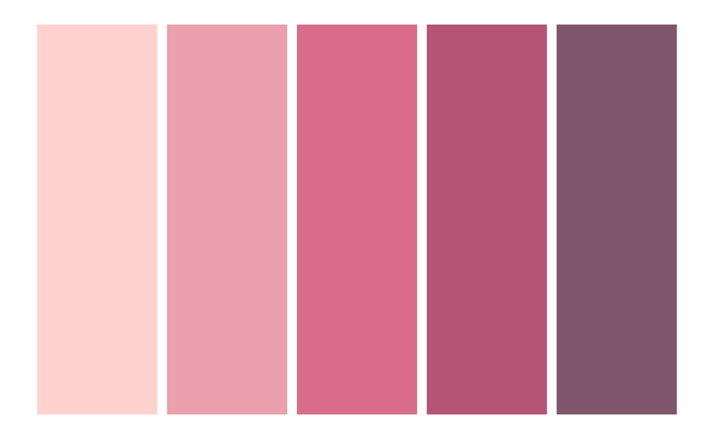

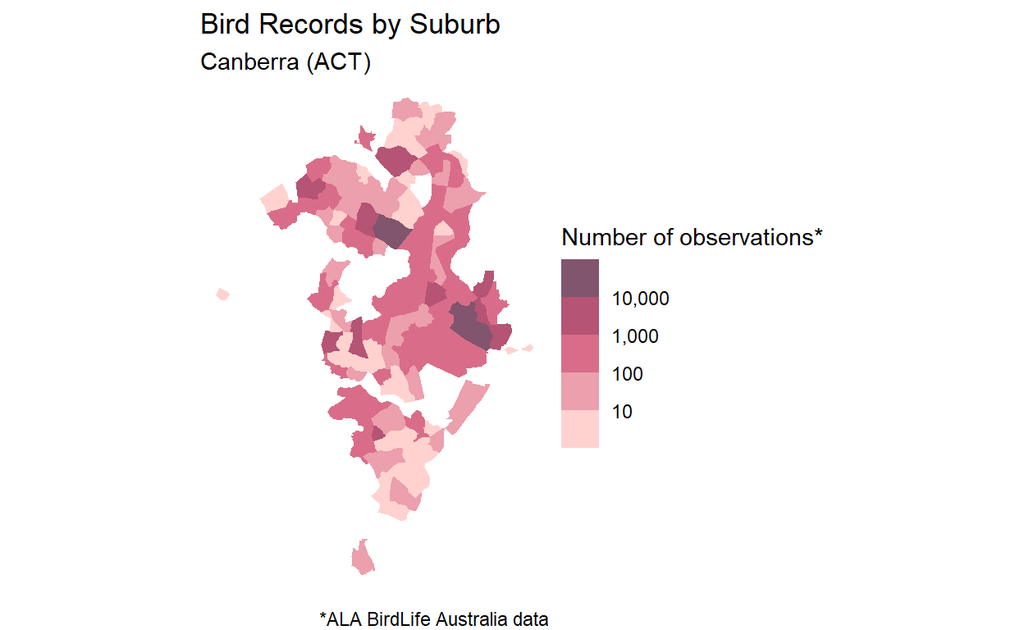

```r
ggplot() +
  geom_sf(
    data = act_counts,
    mapping = aes(fill = counts_discrete),
    colour = "NA"
  ) +
  geom_sf() +
  scale_fill_manual(
    name = "Number of observations*",
    drop = FALSE,
    labels = c("10", "100", "1,000", "10,000"),
    values = galah,
    guide = guide_colorsteps(
      direction = "vertical",
      label.position = "right",
      title.position = "top"
    )
  ) +
  labs(
    title = "Bird Records by Suburb",
    subtitle = "Canberra (ACT)",
    caption = "*ALA BirdLife Australia data"
  ) +
  theme_void()
```

# Final thoughts

There’s not much better than a galah-themed choropleth map!

One way you can extend this map is to add floating labels with `geom_text_repel()` or `geom_label_repel()` from the [`{ggrepel}` package](https://ggrepel.slowkow.com/index.html), which we added for our [final version of our map we posted for National Bird Week 2022](https://twitter.com/atlaslivingaust/status/1582495493308829696). Code to add floating labels can be found [here](https://github.com/AtlasOfLivingAustralia/science/blob/main/comms/2022-10-19_backyard-birds-map/backyard%20birds.Rmd).

You can also [learn how to create a choropleth map with two different colour scales in this ALA Labs post](https://labs.ala.org.au/posts/2022-05-23-ggnewscale/)!

[^1]: Many thanks to Shandiya Balasubramanium for suggesting this method, and for many other very helpful edits!